# Exploratory Data Analysis

Avinash Chakre

February 16, 2019

## R Markdown

We learned importing data, dataframes, matrices and transormation in earlier weeks. Now this section will focus on how to use visualisation and transformation to explore your data in a systematic way, a task that statisticians call exploratory data analysis. Prerequisites - Here we will be combining dplyr ad ggplot2 and we would need to install tidyverse library. As part of EDA we will be covering 1. Variation, 2. Missing Values 3. Covariation 4. Patterns and Models basics.

## Variation

Variation is the tendency of the values of a variable to change from measurement to measurement. You can see variation easily in real life; if you measure any continuous variable twice, you will get two different results. # 7.3.4 Exercises for Variation ##

```r
knitr::opts_chunk$set(echo = FALSE)

library(nycflights13)
library(arm)
library(GGally)
library(tidyverse)
```

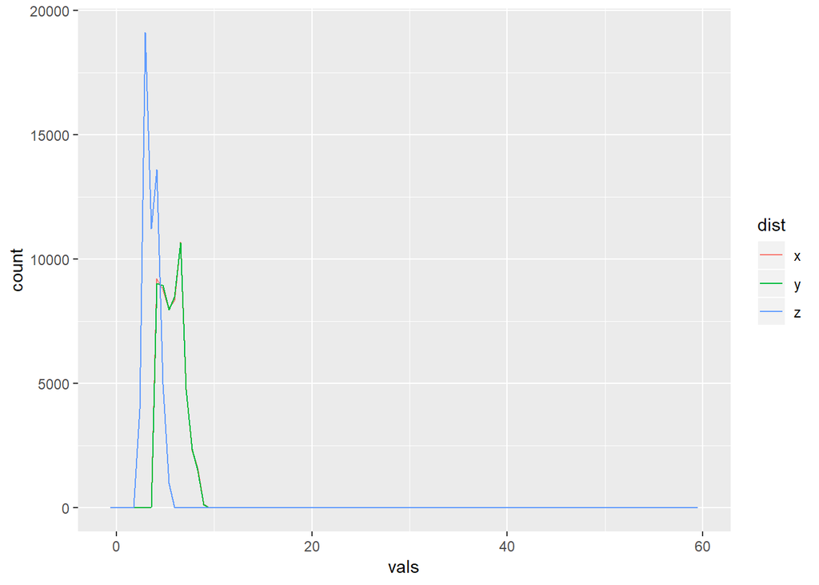

```r
# 1. Explore the distribution of each of the x, y, and z variables in diamonds. What do you learn? Think about a diamond and how you might decide which dimension is the length, width, and depth.
diamonds %>%
  gather(key = dist, vals, x, y, z) %>%
  ggplot(aes(vals, colour = dist)) +
  geom_freqpoly(bins = 100)
```

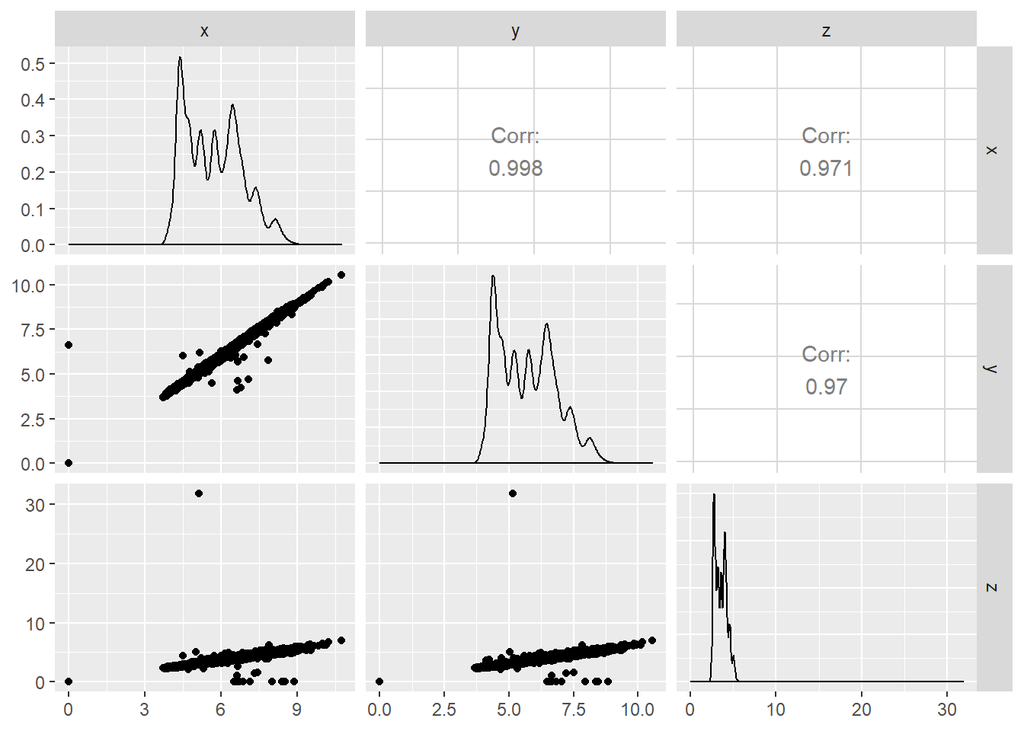

```r
# One thing that is pretty obvious that at first is that the distribution of X and Y are pretty much the same. In fact, the same graph from above with `bins = 30` won't show you the X distribution because it overlaps perfectly. The correlation between the two is `cor(diamonds$x, diamonds$y)`
diamonds %>%
  filter(y < 30) %>%
  select(x, y, z) %>%
  ggpairs()
```